# Survival analysis in R

Lavanya

2025-05-02

## Survival analysis

Survival analysis consists of statistical methods that help us understand and predict how long it takes for an event to occur. These methods help researchers analyze time-to-event data

In the medical world, we typically think of survival analysis literally – tracking time until death. But, it’s more general than that – survival analysis models time until an event occurs (any event). This might be death of a biological organism. But it could also be the time until a hardware failure in a mechanical system, time until recovery, time someone remains unemployed after losing a job, time until a ripe tomato is eaten by a grazing deer, time until someone falls asleep in a workshop, etc. Survival analysis also goes by reliability theory in engineering, duration analysis in economics, and event history analysis in sociology.

## Main Objectives of Survival Analysis

1.Estimate and interpret survival and hazard functions from time-to-event data.

2.Compare survival or hazard functions between different groups or conditions.

3.Evaluate how explanatory variables (like age, treatment, or risk factors) influence survival time.

## Why R

1. Open Source and Cost-Effective
2. Superior Visualization and Reporting
3. Rapid Innovation and Package Ecosystem
4. Interactive Reporting and Dashboards

## Methods used to do survival analysis in R

There are two methods that can be used to perform survival analysis in R

-Kaplan-Meier method

-Cox Proportional hazard model

## to load reqired libraries

## About lung data set

the lung dataset available from the survival package survival. The data contain subjects with advanced lung cancer from the North Central Cancer Treatment Group. It includes the 10 following variables:

inst: Institution code

time: Survival time in days

status: censoring status 1=censored, 2=dead

age: Age in years

sex: Male=1 Female=2

ph.ecog: ECOG performance score as rated by the physician. 0=asymptomatic, 1= symptomatic but completely ambulatory, 2= in bed <50% of the day, 3= in bed > 50% of the day but not bedbound, 4 = bedbound

ph.karno: Karnofsky performance score (bad=0-good=100) rated by physician

pat.karno: Karnofsky performance score (0 = bad, 100 = good) as rated by patient

meal.cal: Calories consumed at meals

wt.loss: Weight loss in last six months

|  | inst | time | status | age | sex | ph.ecog | ph.karno | pat.karno | meal.cal | wt.loss |
| --- | --- | --- | --- | --- | --- | --- | --- | --- | --- | --- |
| 1 | 3 | 306 | 2 | 74 | 1 | 1 | 90 | 100 | 1175 |  |
| 2 | 3 | 455 | 2 | 68 | 1 | 0 | 90 | 90 | 1225 | 15 |
| 3 | 3 | 1010 | 1 | 56 | 1 | 0 | 90 | 90 |  | 15 |
| 4 | 5 | 210 | 2 | 57 | 1 | 1 | 90 | 60 | 1150 | 11 |
| 5 | 1 | 883 | 2 | 60 | 1 | 0 | 100 | 90 |  | 0 |
| 6 | 12 | 1022 | 1 | 74 | 1 | 1 | 50 | 80 | 513 | 0 |
| 7 | 7 | 310 | 2 | 68 | 2 | 2 | 70 | 60 | 384 | 10 |
| 8 | 11 | 361 | 2 | 71 | 2 | 2 | 60 | 80 | 538 | 1 |
| 9 | 1 | 218 | 2 | 53 | 1 | 1 | 70 | 80 | 825 | 16 |
| 10 | 7 | 166 | 2 | 61 | 1 | 2 | 70 | 70 | 271 | 34 |

[output cut: 218 more lines]

## creation of Survival object

## Survival Object

- “survival object” is created using the Surv function from the survival package. This object is used to represent survival data, It typically takes two main arguments , which includes information about the time until an event occurs (such as death, relapse, or failure) and the event status (whether the event has occurred or not).

- Syntax for Surv function [link](https://stat.ethz.ch/R-manual/R-devel/library/survival/html/Surv.html)

```r
lungs <- survival::lung

surv_obj = Surv( time= lungs$time, event = lungs$status == 2)

print(surv_obj)
```

```
##   [1]  306   455  1010+  210   883  1022+  310   361   218   166   170   654
##  [13]  728    71   567   144   613   707    61    88   301    81   624   371
##  [25]  394   520   574   118   390    12   473    26   533   107    53   122
##  [37]  814   965+   93   731   460   153   433   145   583    95   303   519
##  [49]  643   765   735   189    53   246   689    65     5   132   687   345
##  [61]  444   223   175    60   163    65   208   821+  428   230   840+  305
##  [73]   11   132   226   426   705   363    11   176   791    95   196+  167
##  [85]  806+  284   641   147   740+  163   655   239    88   245   588+   30
##  [97]  179   310   477   166   559+  450   364   107   177   156   529+   11
## [109]  429   351    15   181   283   201   524    13   212   524   288   363
## [121]  442   199   550    54   558   207    92    60   551+  543+  293   202
## [133]  353   511+  267   511+  371   387   457   337   201   404+  222    62
## [145]  458+  356+  353   163    31   340   229   444+  315+  182   156   329
## [157]  364+  291   179   376+  384+  268   292+  142   413+  266+  194   320
## [169]  181   285   301+  348   197   382+  303+  296+  180   186   145   269+
## [181]  300+  284+  350   272+  292+  332+  285   259+  110   286   270    81
## [193]  131   225+  269   225+  243+  279+  276+  135    79    59   240+  202+
## [205]  235+  105   224+  239   237+  173+  252+  221+  185+   92+   13   222+
## [217]  192+  183   211+  175+  197+  203+  116   188+  191+  105+  174+  177+
```

in the results plus (+) symbol, which indicates censored observations

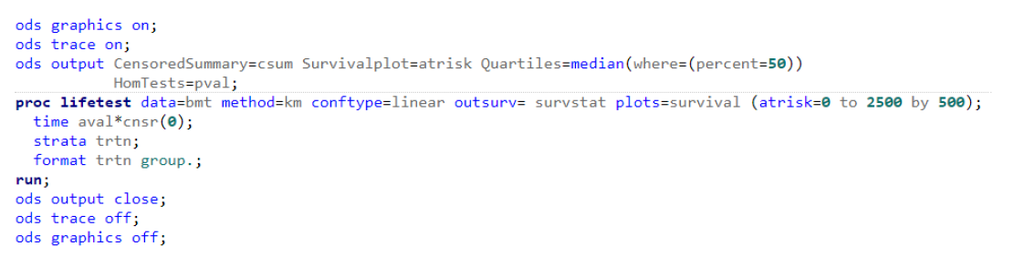

Proc life test in SAS

## create survival statistics

```r
surv_fit=survfit(surv_obj~1,data=lungs)

print(surv_fit)
```

```
## Call: survfit(formula = surv_obj ~ 1, data = lungs)
##
##        n events median 0.95LCL 0.95UCL
## [1,] 228    165    310     285     363
```

```r
surv_fit_by=survfit(surv_obj~sex,data=lungs)

print(surv_fit_by)
```

```
## Call: survfit(formula = surv_obj ~ sex, data = lungs)
##
##         n events median 0.95LCL 0.95UCL
## sex=1 138    112    270     212     310
## sex=2  90     53    426     348     550
```

```r
surv_fit_by2=survfit(surv_obj~sex+ph.ecog,data=lungs)

print(surv_fit_by2)
```

```
## Call: survfit(formula = surv_obj ~ sex + ph.ecog, data = lungs)
##
##    1 observation deleted due to missingness
##                   n events median 0.95LCL 0.95UCL
## sex=1, ph.ecog=0 36     28    353     303     558
## sex=1, ph.ecog=1 71     54    239     207     363
## sex=1, ph.ecog=2 29     28    166     105     288
## sex=1, ph.ecog=3  1      1    118      NA      NA
## sex=2, ph.ecog=0 27      9    705     350      NA
## sex=2, ph.ecog=1 42     28    450     345     687
## sex=2, ph.ecog=2 21     16    239     199     444
```

## survival statistics SAS vs R

-to Produced the same results as SAS survfit(surv.obj ~ 1, conf.type = “log-log”)

```r
surv_fit=survfit(surv_obj~1,data=lung)

print(surv_fit)
```

```
## Call: survfit(formula = surv_obj ~ 1, data = lung)
##
##        n events median 0.95LCL 0.95UCL
## [1,] 228    165    310     285     363
```

```r
surv_fit1=survfit(surv_obj~1,data=lung,conf.type = "log-log")
print(surv_fit1)
```

```
## Call: survfit(formula = surv_obj ~ 1, data = lung, conf.type = "log-log")
##
##        n events median 0.95LCL 0.95UCL
## [1,] 228    165    310     284     361
```

## create summmary of survival statics at each timepoint

```r
evnt_sum<-surv_summary(surv_fit,data=lungs)

print(head(evnt_sum,n=5))
```

```
##   time n.risk n.event n.censor      surv     std.err     upper     lower
## 1    5    228       1        0 0.9956140 0.004395615 1.0000000 0.9870734
## 2   11    227       3        0 0.9824561 0.008849904 0.9996460 0.9655619
## 3   12    224       1        0 0.9780702 0.009916654 0.9972662 0.9592437
## 4   13    223       2        0 0.9692982 0.011786516 0.9919508 0.9471630
## 5   15    221       1        0 0.9649123 0.012628921 0.9890941 0.9413217
```

## survdiff (log-rank p value)

```r
survdiff(surv_obj~sex,data=lungs)
```

```
## Call:
## survdiff(formula = surv_obj ~ sex, data = lungs)
##
##         N Observed Expected (O-E)^2/E (O-E)^2/V
## sex=1 138      112     91.6      4.55      10.3
## sex=2  90       53     73.4      5.68      10.3
##
##  Chisq= 10.3  on 1 degrees of freedom, p= 0.001
```

## Kaplan-Meier using ggsurvplot from survminer ackage

KM Plot is a widely used data visualization method for survival analysis.

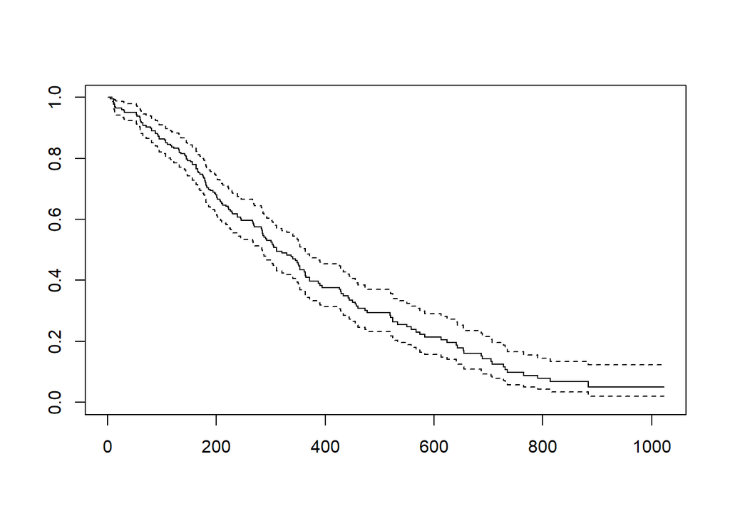

```r
plot(surv_fit)
```

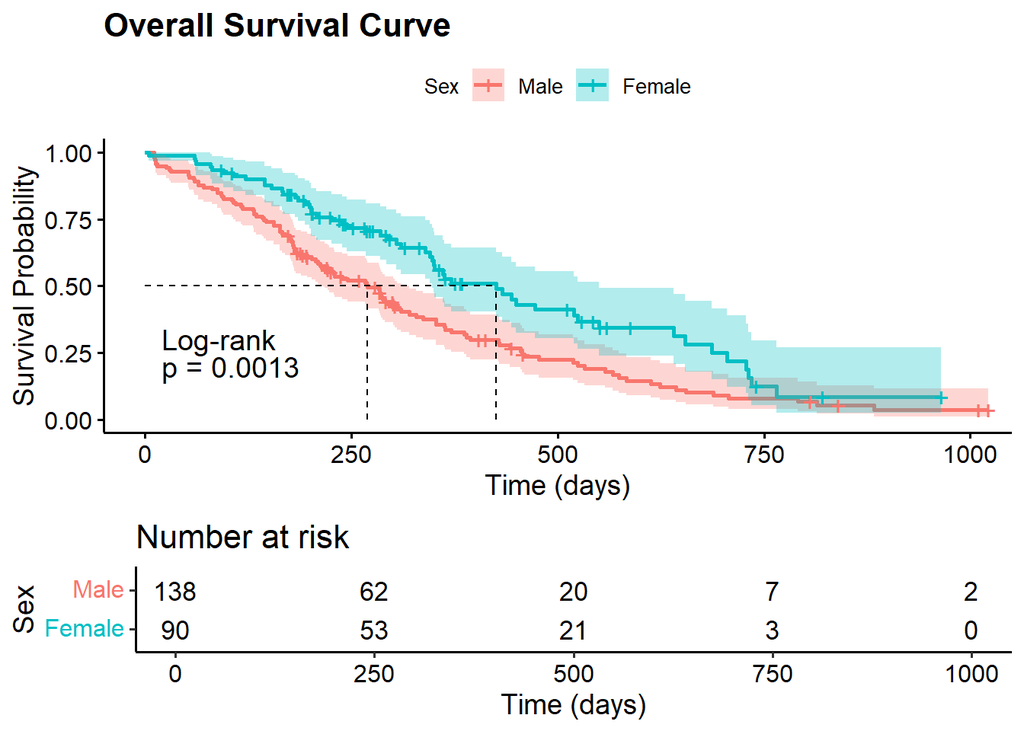

```r
ggsurvplot(surv_fit_by,
           title='Overall Survival Curve',
           xlab='Time (days)',
           ylab='Survival Probability',
           pval.method=TRUE ,
           pval = TRUE,
           surv.median.line="hv",
           legend.title='Sex',
               legend.labs=c('Male' , 'Female'),
           conf.int=TRUE, #shaded confidence intervals (usually 95%) around                                  the survival curves
           risk.table=TRUE,#Displays the number of subjects at risk at                                    different time points below the plot.
           font.title=c(16,"bold"), #font of plot elements
           font.x=c(14), #font size for the x- and y-axis labels
           font.y=c(14),
           font.tickslab=c(12), #font size of the axis tick labels

     surv.plot.height=0.7,# Adjust spacing and proportions
     # Controls the relative height of the survival plot area  (above the risk table).
    # Example: If total height is 1, this means 70% is for the survival plot.
      risk.table.height = 0.3)
```

```r
  # Controls the relative height of the risk table area.
#Together with: surv.plot.height + risk.table.height should ideally equal 1 (though not strictly enforced).

#This means the risk table will take 30% of the plot area.
```

## Hazard ratio

coxph() function from survival package can be used to compute Hazard ratio. A hazard ratio (HR) is the probability of an event in a treatment group relative to the control group probability over a unit of time.

HR = 1: No effect HR < 1: Reduction in the hazard HR > 1: Increase in Hazard

## Cox Regression Handling R vs sas

The default methods for handling ties in a Cox regression model are different which can lead to a different result for the Hazard ratio and associated confidence interval.

-R uses “efron” by default. -SAS uses “breslow” by default.

```r
hr=coxph(surv_obj~sex+age+ph.ecog,data=lungs)
hr1=coxph(surv_obj~sex+age+ph.ecog+age*sex,data=lungs)
summary(hr)
```

```
## Call:
## coxph(formula = surv_obj ~ sex + age + ph.ecog, data = lungs)
##
##   n= 227, number of events= 164
##    (1 observation deleted due to missingness)
##
##              coef exp(coef)  se(coef)      z Pr(>|z|)
## sex     -0.552612  0.575445  0.167739 -3.294 0.000986 ***
## age      0.011067  1.011128  0.009267  1.194 0.232416
## ph.ecog  0.463728  1.589991  0.113577  4.083 4.45e-05 ***
## ---
## Signif. codes:  0 '***' 0.001 '**' 0.01 '*' 0.05 '.' 0.1 ' ' 1
##
##         exp(coef) exp(-coef) lower .95 upper .95
## sex        0.5754     1.7378    0.4142    0.7994
## age        1.0111     0.9890    0.9929    1.0297
## ph.ecog    1.5900     0.6289    1.2727    1.9864
##
## Concordance= 0.637  (se = 0.025 )
## Likelihood ratio test= 30.5  on 3 df,   p=1e-06
## Wald test            = 29.93  on 3 df,   p=1e-06
## Score (logrank) test = 30.5  on 3 df,   p=1e-06
```

```r
hr=coxph(surv_obj~sex+age+ph.ecog,ties = "breslow",data=lungs)
summary(hr)
```

```
## Call:
## coxph(formula = surv_obj ~ sex + age + ph.ecog, data = lungs,
##     ties = "breslow")
##
##   n= 227, number of events= 164
##    (1 observation deleted due to missingness)
##
##              coef exp(coef)  se(coef)      z Pr(>|z|)
## sex     -0.551890  0.575861  0.167742 -3.290    0.001 **
## age      0.011041  1.011102  0.009267  1.191    0.233
## ph.ecog  0.462947  1.588749  0.113574  4.076 4.58e-05 ***
## ---
## Signif. codes:  0 '***' 0.001 '**' 0.01 '*' 0.05 '.' 0.1 ' ' 1
##
##         exp(coef) exp(-coef) lower .95 upper .95
## sex        0.5759     1.7365    0.4145     0.800
## age        1.0111     0.9890    0.9929     1.030
## ph.ecog    1.5887     0.6294    1.2717     1.985
##
## Concordance= 0.637  (se = 0.025 )
## Likelihood ratio test= 30.41  on 3 df,   p=1e-06
## Wald test            = 29.84  on 3 df,   p=1e-06
## Score (logrank) test = 30.41  on 3 df,   p=1e-06
```

## HR by refernce

lowest numeric or alphabetical value is taken as the reference. HR=Hazard(female)/Hazard(male ) - to change the refernce group

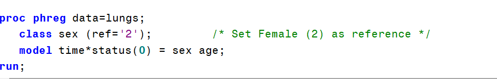

Now the HR will be:

HR=Hazard(Male)/Hazard(Female)

## in R to change the refernce

```r
lungs$sex <- factor(lungs$sex, levels = c(1, 2),
                    labels = c("Male","Female"))

lungs$sex <- relevel(lungs$sex, ref = "Female")

hr_fr=coxph(Surv(time, status) ~ sex + age+ph.ecog, data = lungs)

summary(hr_fr)
```

```
## Call:
## coxph(formula = Surv(time, status) ~ sex + age + ph.ecog, data = lungs)
##
##   n= 227, number of events= 164
##    (1 observation deleted due to missingness)
##
##             coef exp(coef) se(coef)     z Pr(>|z|)
## sexMale 0.552612  1.737787 0.167739 3.294 0.000986 ***
## age     0.011067  1.011128 0.009267 1.194 0.232416
## ph.ecog 0.463728  1.589991 0.113577 4.083 4.45e-05 ***
## ---
## Signif. codes:  0 '***' 0.001 '**' 0.01 '*' 0.05 '.' 0.1 ' ' 1
##
##         exp(coef) exp(-coef) lower .95 upper .95
## sexMale     1.738     0.5754    1.2509     2.414
## age         1.011     0.9890    0.9929     1.030
## ph.ecog     1.590     0.6289    1.2727     1.986
##
## Concordance= 0.637  (se = 0.025 )
## Likelihood ratio test= 30.5  on 3 df,   p=1e-06
## Wald test            = 29.93  on 3 df,   p=1e-06
## Score (logrank) test = 30.5  on 3 df,   p=1e-06
```